# How Study Settings Affect Focus: A Visual Data Story

Vanessa young

## Introduction

This visual data story explores how different environmental and social factors affect observed **focus levels** among students in shared study spaces. Data was collected using a structured Google Form and analysed using R.

This visual data story explores how different study contexts—such as time of day, location, social group size, drink type, and observed activity—affect perceived focus level. The data was collected through observing the individual using a Google Form.The aim is to understand how people study and what factors may influence their attention and noise levels.

Key variables observed:

- Drink type (e.g., coffee, tea, water)
- Activity (e.g., reading, talking, relaxing)
- Focus level (rated 1–10)
- Noise level (rated 1–10)
- Number of study devices used
- Table group size
- Time of day (morning, afternoon, evening)

Data was processed using R with the `{tidyverse}` and `{lubridate}` packages, and visualised with `{ggplot2}`. We used a consistent custom **pink-based colour palette** to support visual storytelling and accessibility.

## Introduction

This visual data story investigates how various **environmental** and **social conditions**—such as drink type, group size, activity type, and time of day—affect the **focus levels** of students observed in shared study environments. The dataset was collected using a structured observational logging form created in Google Forms, designed with a tidy structure to allow for consistent analysis.

Observations were recorded manually across different public and private study spaces such as cafés, libraries, and home environments. The data was imported into R and analysed using the `{tidyverse}`, `{lubridate}`, and `{ggplot2}` packages. All visualisations adopt a **coherent pink-based colour palette**.

The key variables recorded in the study were:

- **Drink type** (e.g., coffee, water, bubble tea)
- **Activity** (e.g., talking, relaxing, studying)
- **Focus level** (rated 1–10)
- **Noise level** (rated 1–10)
- **Number of study devices** used (e.g., laptops, tablets)
- **Social group size** (alone, pair, group)
- **Table group size** (number of people at the same table)
- **Time of day** (morning, afternoon, evening)

### About the Data

The data was collected through structured observational logging in shared study environments such as libraries, cafés, or open campus areas. Each row records a single observation, including:

- A timestamp of when the observation was made
- The activity the student was engaged in (e.g., watching a lecture, typing, relaxing)
- focus level on a scale from 1 to 10
- The drink type the individual was consuming (e.g., water, coffee, energy drink, bubble tea, no drink)
- The location of the observation (e.g., Library, Kate Edgar, Café, Outdoor Area)
- The noise level in the surrounding environment, rated from 1 (very quiet) to 10 (very loud)
- The number of study devices in use at the table (e.g., laptops, tablets, iPads)
- The social group size the individual was part of (e.g., alone, pair, group of 3 or more)
- The table group size, representing how many people were seated at the same table
- The time of day when the observation occurred, recorded in text (e.g., Morning, Afternoon, Evening) and later cleaned for analysis

## plot 1 - Average Focus by Hour and Activity

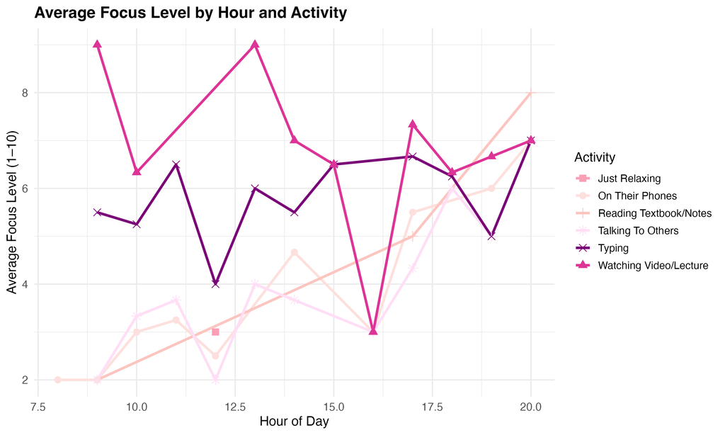

Line plot showing average focus level (1–10) over the course of the day, grouped by activity type. Each line uses a distinct pink-based colour and shape to represent activities like relaxing, watching videos, typing, talking to others, reading, and phone use. Watching videos and typing are associated with higher focus levels, especially in the morning and late afternoon. Relaxing and talking show lower focus.

This line plot explores how **average focus levels fluctuate throughout the day** depending on the type of activity students were engaged in.

This plot illustrates how **average focus levels vary by hour of the day** depending on what activity a student was engaged in while being observed. Each line represents one of the six most common activities recorded in our dataset, and is styled using a **distinct shape and pink-based colour** from our custom palette. This visualisation is crucial for identifying how behavioural patterns influence cognitive engagement throughout the day.

- A timestamp of when the observation was made
- The activity the student was engaged in (e.g., watching a lecture, typing, relaxing)
- A self-assessed or externally rated **focus level** on a scale from 1 to 10

We extracted the **hour** from each timestamp and then grouped the data by hour and activity type. For each group, we calculated the average focus level, resulting in a line graph that reveals activity-specific focus trends throughout the day.